# Self-Driving Car Engineer Nanodegree

## Project: Build a Traffic Sign Recognition Classifier

In this notebook, a template is provided for you to implement your functionality in stages, which is required to successfully complete this project. If additional code is required that cannot be included in the notebook, be sure that the Python code is successfully imported and included in your submission if necessary.

In addition to implementing code, there is a writeup to complete. The writeup should be completed in a separate file, which can be either a markdown file or a pdf document. There is a [write up template](https://github.com/udacity/CarND-Traffic-Sign-Classifier-Project/blob/master/writeup_template.md) that can be used to guide the writing process. Completing the code template and writeup template will cover all of the [rubric points](https://review.udacity.com/#!/rubrics/481/view) for this project.

The [rubric](https://review.udacity.com/#!/rubrics/481/view) contains "Stand Out Suggestions" for enhancing the project beyond the minimum requirements. The stand out suggestions are optional. If you decide to pursue the "stand out suggestions", you can include the code in this Ipython notebook and also discuss the results in the writeup file.

> **Note:** Code and Markdown cells can be executed using the **Shift + Enter** keyboard shortcut. In addition, Markdown cells can be edited by typically double-clicking the cell to enter edit mode.

## Step 0: Load The Data

```python
# Load pickled data
import pickle

# TODO: Fill this in based on where you saved the training and testing data

training_file = 'train.p'
validation_file= 'valid.p'
testing_file = 'test.p'

with open(training_file, mode='rb') as f:
    train = pickle.load(f)
with open(validation_file, mode='rb') as f:
    valid = pickle.load(f)
with open(testing_file, mode='rb') as f:
    test = pickle.load(f)

X_train, y_train = train['features'], train['labels']
X_valid, y_valid = valid['features'], valid['labels']
X_test, y_test = test['features'], test['labels']
```

# Step 1: Dataset Summary & Exploration

The pickled data is a dictionary with 4 key/value pairs:

- `'features'` is a 4D array containing raw pixel data of the traffic sign images, (num examples, width, height, channels).
- `'labels'` is a 1D array containing the label/class id of the traffic sign. The file `signnames.csv` contains id -> name mappings for each id.
- `'sizes'` is a list containing tuples, (width, height) representing the original width and height the image.
- `'coords'` is a list containing tuples, (x1, y1, x2, y2) representing coordinates of a bounding box around the sign in the image. **THESE COORDINATES ASSUME THE ORIGINAL IMAGE. THE PICKLED DATA CONTAINS RESIZED VERSIONS (32 by 32) OF THESE IMAGES**

Complete the basic data summary below. Use python, numpy and/or pandas methods to calculate the data summary rather than hard coding the results. For example, the [pandas shape method](http://pandas.pydata.org/pandas-docs/stable/generated/pandas.DataFrame.shape.html) might be useful for calculating some of the summary results.

## Dataset Summary

As it was requested, we generated a basic summary of the data set.

- Number of training examples
- Number of validting examples
- Number of testing examples
- Image data shape
- Number of classes

```python
import numpy as np
### Replace each question mark with the appropriate value.
### Use python, pandas or numpy methods rather than hard coding the results

# TODO: Number of training examples
n_train = X_train.shape[0]
#...X_train.shape[0] ==> Num examples
#...X_train.shape[1] ==> width
#...X_train.shape[2] ==> height
#...X_train.shape[3] ==> channels

# TODO: Number of validation examples
n_validation = X_valid.shape[0]

# TODO: Number of testing examples.
n_test = X_test.shape[0]

# TODO: What's the shape of an traffic sign image?
image_shape = X_train.shape[1:]

# TODO: How many unique classes/labels there are in the dataset.
n_classes = len(np.unique(y_test))

print("Number of training examples =", n_train)
print("Number of validting examples =", n_validation)
print("Number of testing examples =", n_test)
print("Image data shape =", image_shape)
print("Number of classes =", n_classes)
```

```
Number of training examples = 34799
Number of validting examples = 4410
Number of testing examples = 12630
Image data shape = (32, 32, 3)
Number of classes = 43
```

## Exploratory Visualization

### Explanatory visualization on the dataset

In order to explore dataset, the code performs a random choose of some traffic signs. Every sign is labeled with its respective name in order to facilitate its identification.

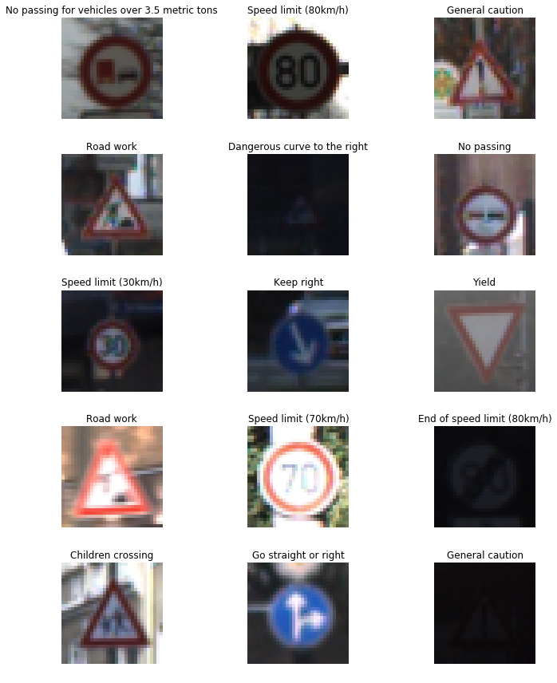

```python
### Data exploration visualization code goes here.
### Feel free to use as many code cells as needed.
import matplotlib.pyplot as plt
# Visualizations will be shown in the notebook.
%matplotlib inline
import random
import csv

def dataset_visualization(data_set, data_set_class, nrows = 4, ncols = 3, random_flag='true'):
    fig, axs = plt.subplots(ncols=ncols, nrows=nrows, figsize=(10, 12))
    axs = axs.ravel()

    n_data_set = data_set.shape[0]
    labels_vec = {}
    figures_vec = {}

    index = -1
    # Getting string names from csv file
    name_string_values = np.genfromtxt('signnames.csv', skip_header=1, dtype=[('myint','i8'), ('mysring','S55')], delimiter=',')
    for ii in range(nrows*ncols):
        if (random_flag == 'true'):
            index = random.randint(0, n_data_set-1)
        else:
            index = index + 1
            #index = np.array(list(range(0,n_data_set-1)))
        label = name_string_values[data_set_class[index]][1].decode('ascii')
        figure = data_set[index]

        axs[ii].imshow(figure.squeeze())
        axs[ii].set_title(label)
        axs[ii].set_axis_off()

    plt.tight_layout()

# Running custome data set visualization as requested
dataset_visualization(X_train, y_train, nrows = 5, ncols = 3)
#plt.imshow(X_train[500].squeeze())
```

### Checking distribution for classes groups (valid, test, train)

It is possible to check that there are more examples for specific classes. It could generate a desbalance training.

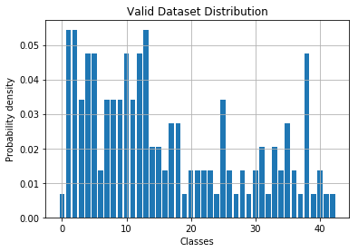

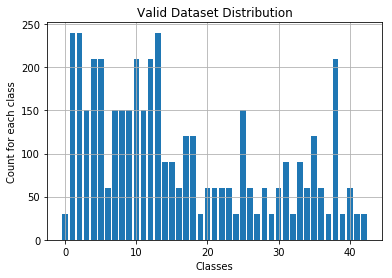

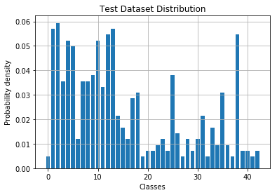

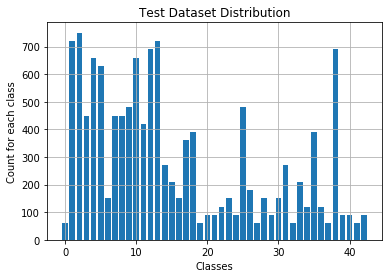

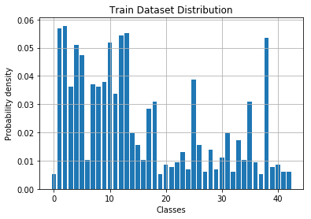

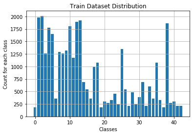

```python
# Checking distribution of classes
ax = plt.gca()

# distribution for Valid classes
#(1)
unique_valid, counts_valid = np.unique(y_valid, return_counts=True)
plt.bar(unique_valid, counts_valid/len(y_valid))
plt.title("Valid Dataset Distribution")
plt.grid()
ax.set_xlabel('Classes')
ax.set_ylabel('Probability density')
plt.show()
#(2)
ax = plt.gca()

unique_valid, counts_valid = np.unique(y_valid, return_counts=True)
plt.bar(unique_valid, counts_valid)
plt.title("Valid Dataset Distribution")
plt.grid()
ax.set_xlabel('Classes')
ax.set_ylabel('Count for each class')
plt.show()



# distribution for Test classes
# (1)
ax = plt.gca()

unique_test, counts_test = np.unique(y_test, return_counts=True)
plt.bar(unique_test, counts_test/len(y_test))
plt.title("Test Dataset Distribution")
plt.grid()
ax.set_xlabel('Classes')
ax.set_ylabel('Probability density')
plt.show()

#(2)
ax = plt.gca()

unique_test, counts_test = np.unique(y_test, return_counts=True)
plt.bar(unique_test, counts_test)
plt.title("Test Dataset Distribution")
plt.grid()
ax.set_xlabel('Classes')
ax.set_ylabel('Count for each class')
plt.show()


# distribution for Train classes
# (1)
ax = plt.gca()

unique_train, counts_train = np.unique(y_train, return_counts=True)
plt.bar(unique_train, counts_train/len(y_train))
plt.title("Train Dataset Distribution")
plt.grid()
ax.set_xlabel('Classes')
ax.set_ylabel('Probability density')
plt.show()

# (2)
ax = plt.gca()

unique_train, counts_train = np.unique(y_train, return_counts=True)
plt.bar(unique_train, counts_train)
plt.title("Train Dataset Distribution")
plt.grid()
ax.set_xlabel('Classes')
ax.set_ylabel('Count for each class')
plt.show()
```

## Step 2: Design and Test a Model Architecture

In this step is described and performed the next stages: preprocessing, model architecture, model training, and solution approach.

### Pre-processing

- Normalization --> to set information between -1 and 1
- Grayscale convertion --> To facilitate processing focusing in just one channel color
- image translation --> To create a duplicated information with random translation in order to create diversity in Train dataset
- image rotation --> To create a duplicated information with random rotation between -12° and 12º in order to create diversity in Train dataset
- image perspective (zoom) --> To create a duplicated information with random perspective in order to create diversity in Train dataset
- duplicating custom images to obtain homonegenous number of samples in the train information

```
(34799, 32, 32, 3)
(32, 32, 3)
```

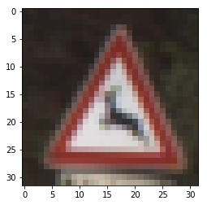

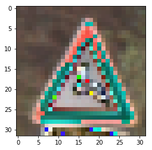

[figure not shown]

```python
### Preprocess the data here. It is required to normalize the data. Other preprocessing steps could include
### converting to grayscale, etc.
### Feel free to use as many code cells as needed.

print(X_train.shape)
print(X_train[4].shape)
plt.imshow(X_train[500].squeeze())

## Normalizing and converting to 32-bit floating point
v128_ref = np.float32(128)
X_train = (X_train.astype(np.float32)-v128_ref)/v128_ref
X_valid = (X_valid.astype(np.float32)-v128_ref)/v128_ref
X_test = (X_test.astype(np.float32)-v128_ref)/v128_ref
#print(X_train.shape)
plt.figure()
plt.imshow(X_train[500].squeeze())

# Converting to grayscale
X_train = np.sum(X_train/3, axis=3, keepdims=True)
X_valid = np.sum(X_valid/3, axis=3, keepdims=True)
X_test = np.sum(X_test/3, axis=3, keepdims=True)
plt.figure()
plt.imshow(X_train[500].squeeze(), cmap="gray")
#print(X_train.shape)
#print(X_train[1].shape)
#plt.imshow(X_train[1].squeeze())
#dataset_visualization(X_train, y_train, nrows = 2, ncols = 2)
#
```

```python
import cv2
#print(X_train[0].shape)

def figure_translation_random(figure):
    dx, dy = np.random.randint(-3, 1, 2)

    #Transformation Matrix
    M = np.float32([[1, 0, dx], [0, 1, dy]])
    dst = cv2.warpAffine(figure, M, (figure.shape[0], figure.shape[1]))
    dst = dst[:,:,None]

    return dst

def figure_rotation_random(figure):
    rows= figure.shape[0]
    cols = figure.shape[1]
    # Random tilt
    tilt = np.random.randint(-12,12,1)
   # print(tilt)

    # Transformation Matrix
    M = cv2.getRotationMatrix2D((cols/2, rows/2),tilt,1)
    dst = cv2.warpAffine(figure,M,(cols,rows))
    return dst

def figure_zoom_random(figure):
    rows= figure.shape[0]
    cols = figure.shape[1]

    # rando generation of numbers between 27 and 32
    r_max = np.random.randint(rows-5, rows)

    # rando generation of numbers between 0 and 5
    r_min = np.random.randint(0,5)

    pts1 = np.float32([[0, 0], [r_max, r_min], [r_min, cols],[rows, r_max]])
    pts2 = np.float32([[0,0],[rows,0],[0,cols],[rows,cols]])

    # Transformation Matrix
    M = cv2.getPerspectiveTransform(pts1, pts2)
    dst = cv2.warpPerspective(figure, M, (rows,cols))
    dst = dst + np.random.normal(0.,0.04,(32,32)).astype(np.float32)

    return dst

def appeding_custom_figures(figure, label_figure, rate_duplication):
    figure_vector = []
    label_vector = []

    for jj in range(rate_duplication):
        translated_image = figure_translation_random(figure)
        rotated_image = figure_rotation_random(translated_image)
        #zoom_image = figure_zoom_random(rotated_image)
        zoom_image = figure_zoom_random(rotated_image)
        figure_vector.append(zoom_image)
        label_vector.append(label_figure)

    figure_vector = np.reshape(figure_vector, (np.shape(figure_vector)[0], 32, 32, 1))
    return np.array(figure_vector), np.array(label_vector)
```

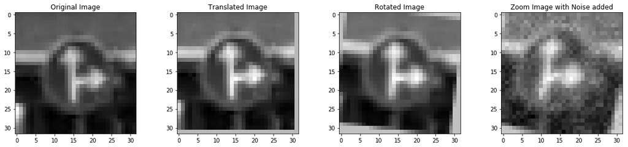

```python
def appeding_custom_figures_to_plot(figure, label_figure, rate_duplication=1):

    for jj in range(rate_duplication):
        fig, ax = plt.subplots(ncols=4, figsize=(20, 4))
        #plt.figure()
        ax[0].imshow(figure.squeeze(), cmap="gray")
        ax[0].set_title("Original Image")
        translated_image = figure_translation_random(figure)
        #plt.figure()
        ax[1].imshow(translated_image.squeeze(), cmap="gray")
        ax[1].set_title("Translated Image")
        rotated_image = figure_rotation_random(translated_image)
        #plt.figure()
        ax[2].imshow(rotated_image.squeeze(), cmap="gray")
        ax[2].set_title("Rotated Image")
        #zoom_image = figure_zoom_random(rotated_image)
        zoom_image = figure_zoom_random(rotated_image)
        #plt.figure()
        ax[3].imshow(zoom_image.squeeze(), cmap="gray")
        ax[3].set_title("Zoom Image with Noise added")


appeding_custom_figures_to_plot(X_train[900], y_train[700])
```

```python
## Pre processing applying Translation, rotation and zoom

# getting histogram information for each label class
unique_train, counts_train = np.unique(y_train, return_counts=True)

#print(X_train.shape)
#print(y_train.shape)

for ii in range(n_classes):

    # Obtaining unique label class values
    label = unique_train[ii]

    # Available samples for each label class
    samples_available = counts_train[ii]

    # looking for unviersal index to increase the right Train matrix that correspond to an specific label class
    result = np.argwhere(y_train == label)
    index_master = int(result[0])

    # In case a label class has less than 1500 samples, we increase it with diverse modified information
    if (samples_available < 1000):

        # the number of repetitiong for every label class
        rate_duplication = 1000-samples_available
        print( "Label evaluated = {} which will be increased to 1000 adding  {} samples".format( label, rate_duplication ) )
        # Generating and concatenating information to be added to master info
        data_extra,label_extra = appeding_custom_figures(X_train[index_master], y_train[index_master], rate_duplication)
      #  f, axarr = plt.subplots(2,2)
       # axarr[0,0].imshow(data_extra[0].squeeze(), cmap="gray")
       # axarr[0,1].imshow(data_extra[1].squeeze(), cmap="gray")
       # axarr[1,0].imshow(data_extra[2].squeeze(), cmap="gray")
       # axarr[1,1].imshow(data_extra[3].squeeze(), cmap="gray")
        #print(label_extra[0:4])


        # Adding data_extra to X_train and label_extra to y_train
        X_train = np.concatenate((X_train, data_extra), axis=0)
        y_train = np.concatenate((y_train, label_extra), axis=0)
```

```
Label evaluated = 0 which will be increased to 1000 adding  820 samples
Label evaluated = 6 which will be increased to 1000 adding  640 samples
Label evaluated = 14 which will be increased to 1000 adding  310 samples
Label evaluated = 15 which will be increased to 1000 adding  460 samples
Label evaluated = 16 which will be increased to 1000 adding  640 samples
Label evaluated = 17 which will be increased to 1000 adding  10 samples
Label evaluated = 19 which will be increased to 1000 adding  820 samples
Label evaluated = 20 which will be increased to 1000 adding  700 samples
Label evaluated = 21 which will be increased to 1000 adding  730 samples
Label evaluated = 22 which will be increased to 1000 adding  670 samples
Label evaluated = 23 which will be increased to 1000 adding  550 samples
Label evaluated = 24 which will be increased to 1000 adding  760 samples
Label evaluated = 26 which will be increased to 1000 adding  460 samples
Label evaluated = 27 which will be increased to 1000 adding  790 samples
Label evaluated = 28 which will be increased to 1000 adding  520 samples
Label evaluated = 29 which will be increased to 1000 adding  760 samples
Label evaluated = 30 which will be increased to 1000 adding  610 samples
Label evaluated = 31 which will be increased to 1000 adding  310 samples
Label evaluated = 32 which will be increased to 1000 adding  790 samples
Label evaluated = 33 which will be increased to 1000 adding  401 samples
Label evaluated = 34 which will be increased to 1000 adding  640 samples
Label evaluated = 36 which will be increased to 1000 adding  670 samples
Label evaluated = 37 which will be increased to 1000 adding  820 samples
Label evaluated = 39 which will be increased to 1000 adding  730 samples
Label evaluated = 40 which will be increased to 1000 adding  700 samples
Label evaluated = 41 which will be increased to 1000 adding  790 samples
Label evaluated = 42 which will be increased to 1000 adding  790 samples
```

```python
from sklearn.utils import shuffle
X_train, y_train = shuffle(X_train, y_train)
print(X_train.shape)
```

```
(51690, 32, 32, 1)
```

### Model Architecture

The LeNet model was used as model architecture. It is exactly the same architecture used in the lab with the main difference that the output was modified to 43.

**Layer 1:** Convolutional. The output shape should be 28x28x6.

**Activation.** rectified linear activation function.

**Pooling.** The output shape should be 14x14x6.

**Layer 2:** Convolutional. The output shape should be 10x10x16.

**Activation.** rectified linear activation function.

**Pooling.** The output shape should be 5x5x16.

**Layer 3:** Fully Connected. This should have 120 outputs.

**Activation.** rectified linear activation function.

**Layer 4:** Fully Connected. This should have 84 outputs.

**Activation.** rectified linear activation function.

**Layer 5:** Fully Connected (Logits). This should have 43 outputs.

```python
### Define your architecture here.
### Feel free to use as many code cells as needed.
import tensorflow as tf
EPOCHS = 100
BATCH_SIZE = 128
dropout_custome = .8
```

```python
from tensorflow.contrib.layers import flatten

### Adding a keep_prob for dropout layers to the argument list.
def custome_LeNet(x, keep_prob):
    # Arguments used for tf.truncated_normal, randomly defines variables for the weights and biases for each layer
    mu = 0
    sigma = 0.1

    # SOLUTION: Layer 1: Convolutional. Input = 32x32x1. Output = 28x28x6.
    conv1_W = tf.Variable(tf.truncated_normal(shape=(5, 5, 1, 6), mean = mu, stddev = sigma))
    conv1_b = tf.Variable(tf.zeros(6))
    conv1   = tf.nn.conv2d(x, conv1_W, strides=[1, 1, 1, 1], padding='VALID') + conv1_b

    # SOLUTION: Activation.
    conv1 = tf.nn.relu(conv1)
    conv1 = tf.nn.dropout(conv1, keep_prob)

    # SOLUTION: Pooling. Input = 28x28x6. Output = 14x14x6.
    conv1 = tf.nn.max_pool(conv1, ksize=[1, 2, 2, 1], strides=[1, 2, 2, 1], padding='VALID')

    # SOLUTION: Layer 2: Convolutional. Output = 10x10x16.
    conv2_W = tf.Variable(tf.truncated_normal(shape=(5, 5, 6, 16), mean = mu, stddev = sigma))
    conv2_b = tf.Variable(tf.zeros(16))
    conv2   = tf.nn.conv2d(conv1, conv2_W, strides=[1, 1, 1, 1], padding='VALID') + conv2_b

    # SOLUTION: Activation.
    conv2 = tf.nn.relu(conv2)
    conv2 = tf.nn.dropout(conv2, keep_prob)

    # SOLUTION: Pooling. Input = 10x10x16. Output = 5x5x16.
    conv2 = tf.nn.max_pool(conv2, ksize=[1, 2, 2, 1], strides=[1, 2, 2, 1], padding='VALID')

    # SOLUTION: Flatten. Input = 5x5x16. Output = 400.
    fc0   = flatten(conv2)

    # SOLUTION: Layer 3: Fully Connected. Input = 400. Output = 120.
    fc1_W = tf.Variable(tf.truncated_normal(shape=(400, 120), mean = mu, stddev = sigma))
    fc1_b = tf.Variable(tf.zeros(120))
    fc1   = tf.matmul(fc0, fc1_W) + fc1_b

    # SOLUTION: Activation.
    fc1 = tf.nn.relu(fc1)
    fc1 = tf.nn.dropout(fc1, keep_prob)

    # SOLUTION: Layer 4: Fully Connected. Input = 120. Output = 84.
    fc2_W  = tf.Variable(tf.truncated_normal(shape=(120, 84), mean = mu, stddev = sigma))
    fc2_b  = tf.Variable(tf.zeros(84))
    fc2    = tf.matmul(fc1, fc2_W) + fc2_b

    # SOLUTION: Activation.
    fc2 = tf.nn.relu(fc2)
    fc2 = tf.nn.dropout(fc2, keep_prob)

    # SOLUTION: Layer 5: Fully Connected. Input = 84. Output = 43.
    fc3_W  = tf.Variable(tf.truncated_normal(shape=(84, 43), mean = mu, stddev = sigma))
    fc3_b  = tf.Variable(tf.zeros(43))
    logits = tf.matmul(fc2, fc3_W) + fc3_b

    return logits, conv1, conv2
```

### Model Training

(Train, Validate and Test the Model)

The optimizer used is based on Cross entropy and softmax tool provided by TensorFlow. batch size=128 because in other cases the training process indicated overfitting. In order to guarantee the convergence of Neural network learning process we used 100 epochs. I have added tunable keep_prob using the variable dropout_custome = 0.8, this dropout layer was inserted after each activation layer (to avoid network overfitting).

```python
### Train your model here.
### Calculate and report the accuracy on the training and validation set.
### Once a final model architecture is selected,
### the accuracy on the test set should be calculated and reported as well.
### Feel free to use as many code cells as needed.
x = tf.placeholder(tf.float32, (None, 32, 32, 1))
y = tf.placeholder(tf.int32, (None))
one_hot_y = tf.one_hot(y, 43)

# defining Dropout layers
keep_prob = tf.placeholder(tf.float32)


## Training Pipeline
rate = 0.001

logits, conv1, conv2  = custome_LeNet(x, keep_prob)
cross_entropy = tf.nn.softmax_cross_entropy_with_logits(labels=one_hot_y, logits=logits)
loss_operation = tf.reduce_mean(cross_entropy)
optimizer = tf.train.AdamOptimizer(learning_rate = rate)
training_operation = optimizer.minimize(loss_operation)

## Model Evaluation
correct_prediction = tf.equal(tf.argmax(logits, 1), tf.argmax(one_hot_y, 1))
accuracy_operation = tf.reduce_mean(tf.cast(correct_prediction, tf.float32))
saver = tf.train.Saver()

def evaluate(X_data, y_data):
    num_examples = len(X_data)
    total_accuracy = 0
    sess = tf.get_default_session()
    for offset in range(0, num_examples, BATCH_SIZE):
        batch_x, batch_y = X_data[offset:offset+BATCH_SIZE], y_data[offset:offset+BATCH_SIZE]
        accuracy = sess.run(accuracy_operation, feed_dict={x: batch_x, y: batch_y, keep_prob: 1.0})
        total_accuracy += (accuracy * len(batch_x))
    return total_accuracy / num_examples

## Training Model
with tf.Session() as sess:
    sess.run(tf.global_variables_initializer())
    #saver.restore(sess, './lenet_1')
    num_examples = len(X_train)

    print("Training...")
    print()
    for i in range(EPOCHS):
        X_train, y_train = shuffle(X_train, y_train)
        for offset in range(0, num_examples, BATCH_SIZE):
            end = offset + BATCH_SIZE
            batch_x, batch_y = X_train[offset:end], y_train[offset:end]
            sess.run(training_operation, feed_dict={x: batch_x, y: batch_y, keep_prob: dropout_custome})

        validation_accuracy = evaluate(X_valid, y_valid)
        print("EPOCH {} ...".format(i+1))
        print("Validation Accuracy = {:.3f}".format(validation_accuracy))
        print()

    saver.save(sess, './lenet.ckpt')
    print("Model saved")
```

```
Training...

EPOCH 1 ...
Validation Accuracy = 0.674

EPOCH 2 ...
Validation Accuracy = 0.799

EPOCH 3 ...
Validation Accuracy = 0.820

EPOCH 4 ...
Validation Accuracy = 0.854

EPOCH 5 ...
Validation Accuracy = 0.874

EPOCH 6 ...
Validation Accuracy = 0.891

EPOCH 7 ...
Validation Accuracy = 0.901

EPOCH 8 ...
Validation Accuracy = 0.905

EPOCH 9 ...
Validation Accuracy = 0.911

EPOCH 10 ...
Validation Accuracy = 0.916

EPOCH 11 ...
Validation Accuracy = 0.892

EPOCH 12 ...
Validation Accuracy = 0.922

EPOCH 13 ...
Validation Accuracy = 0.917
```

[output cut: 248 more lines]

```
Validation Accuracy = 0.953

EPOCH 97 ...
Validation Accuracy = 0.955

EPOCH 98 ...
Validation Accuracy = 0.956

EPOCH 99 ...
Validation Accuracy = 0.958

EPOCH 100 ...
Validation Accuracy = 0.953

Model saved
```

### Solution Approach

In spite that I run 100 epochs the training process indicates that validation accuracy was greated than 0.93 in the epoch 15 (the first time). After training we evaluated the Accuracy and I got an accuracy of 0.932 as it is described in following lines.

```python
with tf.Session() as sess:
    saver.restore(sess, './lenet.ckpt')
    test_accuracy = evaluate(X_test, y_test)
    print("Test Accuracy = {:.3f}".format(test_accuracy))
```

```
Test Accuracy = 0.932
```

## Step 3: Test a Model on New Images

### Acquiring New Images

I included five new German Traffic signs found on the web. They are visualized in the following lines and described in following lines. They are saved in the folder 'custome_signs_web/'

- 'speed_20km_0.jpg'
- 'no_passing_9.jpg'
- 'yield_13.jpg'
- 'slipperyroad_23.jpg'
- 'keep_right_38.jpg'

The main particularity in all cases is the image resolution. In case of Yield signal it included a custome background of clouds, it is similar in the case of Speed limit (20km/h) signal.

### Load and Output the Images

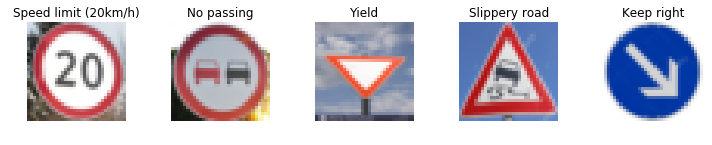

```python
### Load the images and plot them here.
### Feel free to use as many code cells as needed.
import matplotlib.image as mpimg
import scipy.misc as scms

web_samples = 5
cols = 32
rows = 32
rgb_dimension = 3
X_images = np.zeros((web_samples,rows,rows,rgb_dimension),dtype=np.uint8)

names = ['speed_20km_0.jpg','no_passing_9.jpg','yield_13.jpg','slipperyroad_23.jpg','keep_right_38.jpg']
directory = 'custome_signs_web/'

y_images = np.array([0,9,13,23,38,])

for name_image,ii in zip(names, range(0,5)):
    image = mpimg.imread(directory+name_image)
    image_resized = scms.imresize(image, (32,32,3))
    X_images[ii] = image_resized

# Visualization of custome data obtained from web
dataset_visualization(X_images, y_images, nrows = 1, ncols = 5, random_flag='false')
```

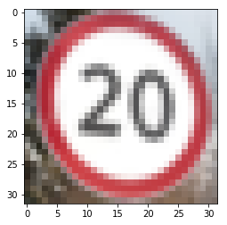

[figure not shown]

[figure not shown]

```python
## Normalizing and converting to 32-bit floating point
plt.figure()
plt.imshow(X_images[0].squeeze())
v128_ref = np.float32(128)
X_images = (X_images.astype(np.float32)-v128_ref)/v128_ref
#print(X_train.shape)
plt.figure()
plt.imshow(X_images[0].squeeze())
# Converting to grayscale
X_images = np.sum(X_images/3, axis=3, keepdims=True)
plt.figure()
plt.imshow(X_images[0].squeeze(), cmap="gray")

#print(X_train.shape)
#print(X_train[1].shape)
#plt.imshow(X_train[1].squeeze())
#dataset_visualization(X_train, y_train, nrows = 2, ncols = 2)
#
```

### Performance on New Images

In this step I document the performance of the model trained before, this performance is evaluated using the 5 figures obtained from the Internet. The accuracy results of prediction were excelent in all cases. So, accuracy was 100% for these samples.

```
Output classes:
Expected Labels:
       0 ,
       9 ,
       13 ,
       23 ,
       38
Actual:
[ 0  9 13 23 38]
```

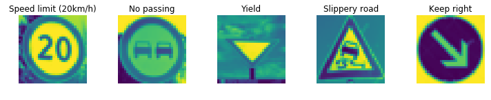

```python
### Run the predictions here and use the model to output the prediction for each image.
### Make sure to pre-process the images with the same pre-processing pipeline used earlier.
### Feel free to use as many code cells as needed.
prediction = tf.argmax( logits, 1 )
saver = tf.train.Saver()

with tf.Session() as sess:
    # Load the weights and bias
    saver.restore(sess, './lenet.ckpt')
    predictions = sess.run(prediction, feed_dict={
        x: X_images,
        keep_prob: 1.0})

print("Output classes:")
print("Expected Labels: \n\
       0 , \n\
       9 , \n\
       13 , \n\
       23 , \n\
       38 ")
#'speed_20km_0.jpg','no_passing_9.jpg','yield_13.jpg','slipperyroad_23.jpg','keep_right_38.jpg'
print('Actual:')
print(predictions)

dataset_visualization(X_images, predictions, nrows = 1, ncols = 5, random_flag='false')
```

Analyze Performance

```python
### Calculate the accuracy for these 5 new images.
### For example, if the model predicted 1 out of 5 signs correctly, it's 20% accurate on these new images.
with tf.Session() as sess:
    saver.restore(sess,'./lenet.ckpt')
    accuracy = sess.run(accuracy_operation, feed_dict={
            x: X_images,
            y: y_images,
            keep_prob: 1.0})
    print( "Accuracy = {}%".format( accuracy*100. ) )
```

```
Accuracy = 100.0%
```

### Model Certainty - Softmax Probabilities --> For Each Image Found on the Web

The top five softmax probabilities of the predictions on the captured images are outputted (check the following cells). In all cases the model is certain achieving a probability of 1 or near to 1 for all signs.

For each of the new images, print out the model's softmax probabilities to show the **certainty** of the model's predictions (limit the output to the top 5 probabilities for each image). [`tf.nn.top_k`](https://www.tensorflow.org/versions/r0.12/api_docs/python/nn.html#top_k) could prove helpful here.

The example below demonstrates how tf.nn.top_k can be used to find the top k predictions for each image.

`tf.nn.top_k` will return the values and indices (class ids) of the top k predictions. So if k=3, for each sign, it'll return the 3 largest probabilities (out of a possible 43) and the correspoding class ids.

Take this numpy array as an example. The values in the array represent predictions. The array contains softmax probabilities for five candidate images with six possible classes. `tf.nn.top_k` is used to choose the three classes with the highest probability:

```
# (5, 6) array
a = np.array([[ 0.24879643,  0.07032244,  0.12641572,  0.34763842,  0.07893497,
         0.12789202],
       [ 0.28086119,  0.27569815,  0.08594638,  0.0178669 ,  0.18063401,
         0.15899337],
       [ 0.26076848,  0.23664738,  0.08020603,  0.07001922,  0.1134371 ,
         0.23892179],
       [ 0.11943333,  0.29198961,  0.02605103,  0.26234032,  0.1351348 ,
         0.16505091],
       [ 0.09561176,  0.34396535,  0.0643941 ,  0.16240774,  0.24206137,
         0.09155967]])
```

Running it through `sess.run(tf.nn.top_k(tf.constant(a), k=3))` produces:

```
TopKV2(values=array([[ 0.34763842,  0.24879643,  0.12789202],
       [ 0.28086119,  0.27569815,  0.18063401],
       [ 0.26076848,  0.23892179,  0.23664738],
       [ 0.29198961,  0.26234032,  0.16505091],
       [ 0.34396535,  0.24206137,  0.16240774]]), indices=array([[3, 0, 5],
       [0, 1, 4],
       [0, 5, 1],
       [1, 3, 5],
       [1, 4, 3]], dtype=int32))
```

Looking just at the first row we get `[ 0.34763842, 0.24879643, 0.12789202]`, you can confirm these are the 3 largest probabilities in `a`. You'll also notice `[3, 0, 5]` are the corresponding indices.

```
Softmax probabilities - Analysis:

speed_20km_0.jpg:
Probabilities
[  9.90918875e-01   9.03982855e-03   2.12994564e-05   9.12362248e-06
   5.63192771e-06]
Corresponding labels
[ 0  8 23  5 40]

no_passing_9.jpg:
Probabilities
[  9.99756873e-01   1.77435606e-04   6.11053983e-05   2.54077281e-06
   2.11964198e-06]
Corresponding labels
[ 9 17 41 12 40]

yield_13.jpg:
Probabilities
[  1.00000000e+00   4.35757386e-09   9.36835720e-10   8.33410563e-10
   3.80390330e-10]
Corresponding labels
[13 36 15 22  4]

slipperyroad_23.jpg:
Probabilities
[  1.00000000e+00   1.97149692e-11   4.12468372e-13   2.30945884e-15
   1.38389368e-16]
Corresponding labels
[23 20 19 31 30]

keep_right_38.jpg:
Probabilities
[  1.00000000e+00   3.94126768e-14   1.31525630e-17   6.98550925e-19
   5.73060337e-19]
Corresponding labels
[38 23  2  5  8]
```

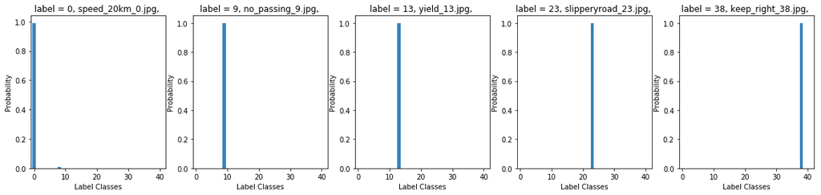

```python
### Print out the top five softmax probabilities for the predictions on the German traffic sign images found on the web.
### Feel free to use as many code cells as needed.
softmax_prob_k = tf.nn.top_k(tf.nn.softmax(logits),5)

with tf.Session() as sess:
    # Load the weights and bias
    saver.restore(sess, './lenet.ckpt')
    output = sess.run(softmax_prob_k, feed_dict={
        x: X_images,
        keep_prob: 1.0})

print("Softmax probabilities - Analysis:")
fig, ax = plt.subplots(ncols=5, figsize=(20, 4))
for i in range(5):
    print()
    print( "{}:".format( names[i] ) )
    print( "Probabilities")
    print(output.values[i])
    print( "Corresponding labels")
    print(output.indices[i])
    ax[i].bar(output.indices[i],output.values[i], align='center', alpha=0.9, width=1)
    ax[i].set_xlim([-1, 42])
    ax[i].set_title("label = {}, {}, ".format( y_images[i], names[i] ))
    ax[i].set_xlabel('Label Classes')
    ax[i].set_ylabel('Probability')
```

### Project Writeup

Once you have completed the code implementation, document your results in a project writeup using this [template](https://github.com/udacity/CarND-Traffic-Sign-Classifier-Project/blob/master/writeup_template.md) as a guide. The writeup can be in a markdown or pdf file.